# Lab 2

Stephanie Gluck

1/15/2020

```r
d <- rio::import("https://github.com/fivethirtyeight/data/raw/master/alcohol-consumption/drinks.csv")
```

### Histogram

Default histgram

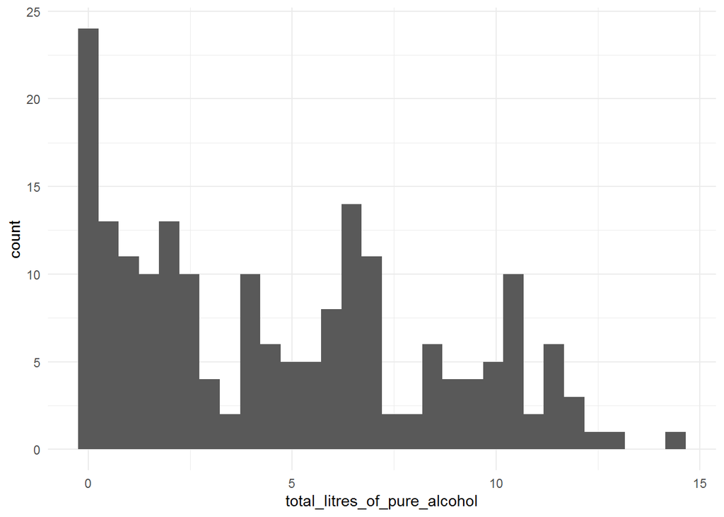

```r
theme_set(theme_minimal())

ggplot(d, aes(x = total_litres_of_pure_alcohol)) +
  geom_histogram()
```

Histogram with bin = 18

I selected the bin = 18 option as I wanted to demonstrate that overall there is quite a bit of variability in the data and it does not follow a normal ditribution for the total liters of alcohol comsumption in each country. While many countries consumed zero liters or less than 5 liters of alcohol as indicated by the slight positive skewness of the histogram, there are also a good amount of countries throughout the data that consumed a varied amount of alcohol.

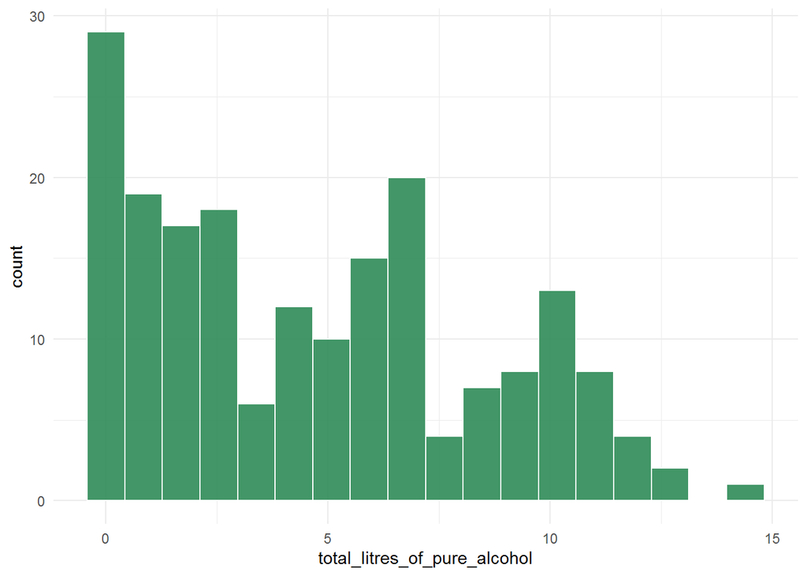

```r
ggplot(d, aes(x = total_litres_of_pure_alcohol)) +
  geom_histogram(fill = "seagreen4",
                 color = "white",
                 alpha = 0.9,
                 bins = 18)
```

### Density Plot

Default density plot

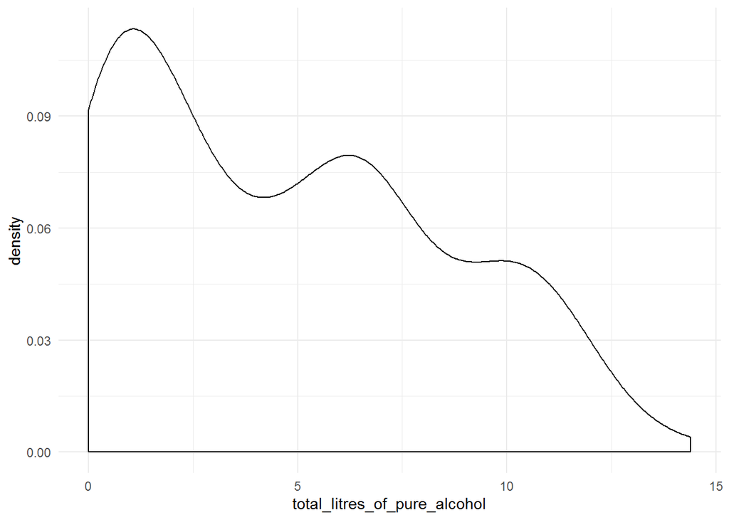

```r
ggplot(d, aes(total_litres_of_pure_alcohol)) +
  geom_density()
```

Density plot bw = 0.1

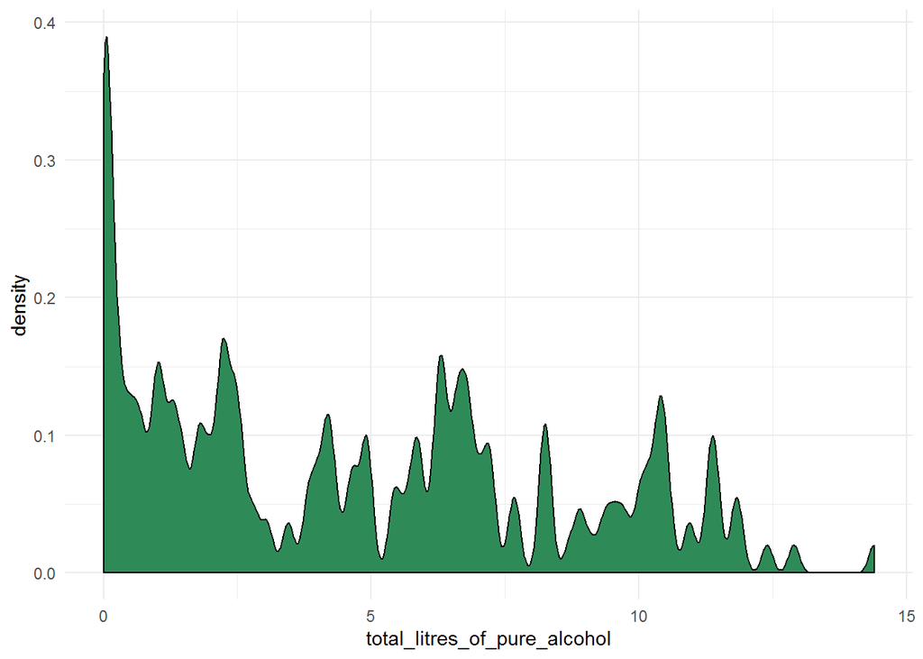

```r
ggplot(d, aes(total_litres_of_pure_alcohol)) +
  geom_density(fill = "seagreen4",
               bw = 0.1)
```

Density plot bw = 0.4

I seleted the bandwidth size of 0.4 because similar to the histogram, I wanted to capture the variability in the data to demonstrate that while a large number of countries consumed none or less than 5 liters of alcohol as shown by the slight positive skew of the density plot, there were also several countries with varied greater level of alcohol consumption.

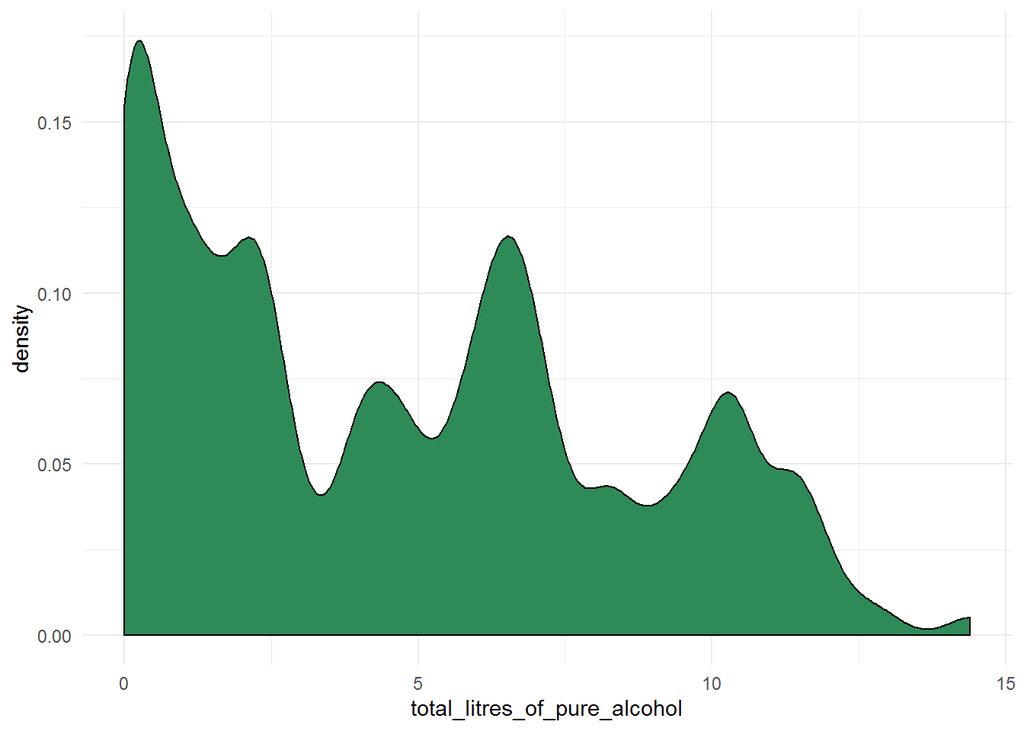

```r
ggplot(d, aes(total_litres_of_pure_alcohol)) +
  geom_density(fill = "seagreen4",
               bw = 0.4)
```